# COMPSCIX 415.2 Homework 5/Midterm

Xinmiao Tan

July 11, 2018

My Github repository for my assignments can be found at this URL: https://github.com/xinmiaotan/compscix-415-2-assignments

## Table of Content

### A. RStudio and R Markdown (3 points)

### B. The tidyverse packages (3 points)

### C. R Basics (1.5 points)

### D. Data import/export (3 points)

### E. Visualization (6 points)

### F. Data munging and wrangling (6 points)

### G. EDA (6 points)

### H. Git and Github (1.5 points)

```r
library(tidyverse)
library(ggplot2)
```

### A. RStudio and R Markdown (3 points)

#### 1. Use markdown headers in your document to clearly separate each midterm question and add a table of contents to your document.

### B. The tidyverse packages (3 points)

#### 1. Can you name which package is associated with each task below?

Plotting - ggplot2 Data munging/wrangling - tidyverse Reshaping (speading and gathering) data - tidyr Importing/exporting data - readr

#### 2. Now can you name two functions that you’ve used from each package that you listed above for these tasks?

Plotting - ggplot2: geom_bar(), geom_point()

Data munging/wrangling - tidyverse: group_by(), summarize()

Reshaping (speading and gathering) data - tidyr: gather(key = , value = ), spread(key = , value = )

Importing/exporting data - readr: write_csv(), read_csv(path = )

### C. R Basics (1.5 points)

#### 1. Fix this code with the fewest number of changes possible so it works:

```r
data_name <- c( 1 , 2 , 3 )
data_name
```

```
## [1] 1 2 3
```

#### 2. Fix this code so it works:

```r
my_string <- c('has', 'an', 'error', 'in', 'it')
my_string
```

```
## [1] "has"   "an"    "error" "in"    "it"
```

#### 3. Look at the code below and comment on what happened to the values in the vector.

```r
my_vector <- c('1', '2', '3', '4', '5')
my_vector
```

```
## [1] "1" "2" "3" "4" "5"
```

### D. Data import/export (3 points)

#### 1. Download the rail_trail.txt file from Canvas (in the Midterm Exam section) and successfully import it into R. Prove that it was imported successfully by including your import code and taking a glimpse of the result.

```r
rail_trail <- read_delim(file = '/Users/xinmiaotan/Desktop/Data Science/R/IntroR/Lec5/rail_trail.txt',delim='|')
glimpse(rail_trail)
```

```
## Observations: 90
## Variables: 10
## $ hightemp   <int> 83, 73, 74, 95, 44, 69, 66, 66, 80, 79, 78, 65, 41,...
## $ lowtemp    <int> 50, 49, 52, 61, 52, 54, 39, 38, 55, 45, 55, 48, 49,...
## $ avgtemp    <dbl> 66.5, 61.0, 63.0, 78.0, 48.0, 61.5, 52.5, 52.0, 67....
## $ spring     <int> 0, 0, 1, 0, 1, 1, 1, 1, 0, 0, 0, 1, 1, 0, 0, 1, 0, ...
## $ summer     <int> 1, 1, 0, 1, 0, 0, 0, 0, 1, 1, 1, 0, 0, 0, 0, 0, 1, ...
## $ fall       <int> 0, 0, 0, 0, 0, 0, 0, 0, 0, 0, 0, 0, 0, 1, 1, 0, 0, ...
## $ cloudcover <dbl> 7.6, 6.3, 7.5, 2.6, 10.0, 6.6, 2.4, 0.0, 3.8, 4.1, ...
## $ precip     <dbl> 0.00, 0.29, 0.32, 0.00, 0.14, 0.02, 0.00, 0.00, 0.0...
## $ volume     <int> 501, 419, 397, 385, 200, 375, 417, 629, 533, 547, 4...
## $ weekday    <int> 1, 1, 1, 0, 1, 1, 1, 0, 0, 1, 1, 1, 1, 1, 1, 1, 0, ...
```

#### 2. Export the file into a comma-separated file and name it “rail_trail.csv”. Make sure you define the path correctly so that you know where it gets saved. Then reload the file. Include your export and import code and take another glimpse.

```r
write_delim(rail_trail, delim=',', path = '/Users/xinmiaotan/Desktop/Data Science/R/IntroR/Lec5/rail_trail.csv')
rail_trail_csv <- read_delim(file = '/Users/xinmiaotan/Desktop/Data Science/R/IntroR/Lec5/rail_trail.csv',delim=',')
glimpse(rail_trail_csv)
```

```
## Observations: 90
## Variables: 10
## $ hightemp   <int> 83, 73, 74, 95, 44, 69, 66, 66, 80, 79, 78, 65, 41,...
## $ lowtemp    <int> 50, 49, 52, 61, 52, 54, 39, 38, 55, 45, 55, 48, 49,...
## $ avgtemp    <dbl> 66.5, 61.0, 63.0, 78.0, 48.0, 61.5, 52.5, 52.0, 67....
## $ spring     <int> 0, 0, 1, 0, 1, 1, 1, 1, 0, 0, 0, 1, 1, 0, 0, 1, 0, ...
## $ summer     <int> 1, 1, 0, 1, 0, 0, 0, 0, 1, 1, 1, 0, 0, 0, 0, 0, 1, ...
## $ fall       <int> 0, 0, 0, 0, 0, 0, 0, 0, 0, 0, 0, 0, 0, 1, 1, 0, 0, ...
## $ cloudcover <dbl> 7.6, 6.3, 7.5, 2.6, 10.0, 6.6, 2.4, 0.0, 3.8, 4.1, ...
## $ precip     <dbl> 0.00, 0.29, 0.32, 0.00, 0.14, 0.02, 0.00, 0.00, 0.0...
## $ volume     <int> 501, 419, 397, 385, 200, 375, 417, 629, 533, 547, 4...
## $ weekday    <int> 1, 1, 1, 0, 1, 1, 1, 0, 0, 1, 1, 1, 1, 1, 1, 1, 0, ...
```

### E. Visualization (6 points)

1. Not easy to visualize the percentage of Yes or No, should use bar or histogram.
2. Should not put age and gender in the same figure. Should seperate them into two figures, one comparing age and other one comparing gender.
3. Should use different color for different age groups.

#### 2. Reproduce this graphic using the diamonds data set.

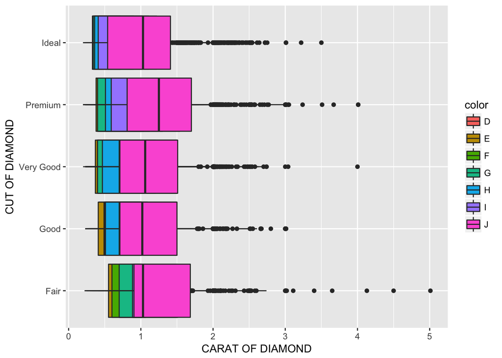

```r
data(diamonds)

ggplot(data = diamonds, aes(x = cut, y = carat)) +
    geom_boxplot(aes(fill=color), position=position_dodge(width = 0), width=6) +
    coord_flip() +
    xlab('CUT OF DIAMOND') +
    ylab('CARAT OF DIAMOND')
```

#### 3. The previous graphic is not very useful. We can make it much more useful by changing one thing about it. Make the change and plot it again.

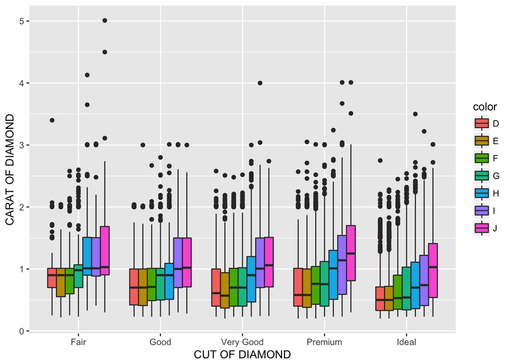

```r
ggplot(data = diamonds, aes(x = cut, y = carat)) +
    geom_boxplot(aes(fill=color)) +
    xlab('CUT OF DIAMOND') +
    ylab('CARAT OF DIAMOND')
```

### F. Data munging and wrangling (6 points)

#### 1. Is this data “tidy”? If yes, leave it alone and go to the next problem. If no, make it tidy. Note: this data set is called table2 and is available in the tidyverse package. It should be ready for you to use after you’ve loaded the tidyverse package.

```r
table2
```

```
## # A tibble: 12 x 4
##        country  year       type      count
##          <chr> <int>      <chr>      <int>
##  1 Afghanistan  1999      cases        745
##  2 Afghanistan  1999 population   19987071
##  3 Afghanistan  2000      cases       2666
##  4 Afghanistan  2000 population   20595360
##  5      Brazil  1999      cases      37737
##  6      Brazil  1999 population  172006362
##  7      Brazil  2000      cases      80488
##  8      Brazil  2000 population  174504898
##  9       China  1999      cases     212258
## 10       China  1999 population 1272915272
## 11       China  2000      cases     213766
## 12       China  2000 population 1280428583
```

```r
table2_tidy <- table2 %>% spread(key = type, value = count)
table2_tidy
```

```
## # A tibble: 6 x 4
##       country  year  cases population
##         <chr> <int>  <int>      <int>
## 1 Afghanistan  1999    745   19987071
## 2 Afghanistan  2000   2666   20595360
## 3      Brazil  1999  37737  172006362
## 4      Brazil  2000  80488  174504898
## 5       China  1999 212258 1272915272
## 6       China  2000 213766 1280428583
```

#### 2. Create a new column in the diamonds data set called price_per_carat that shows the price of each diamond per carat (hint: divide). Only show me the code, not the output.

```r
diamonds <- diamonds %>% mutate(price_per_carat=price/carat)
```

#### 3. For each cut of diamond in the diamonds data set, how many diamonds, and what proportion, have a price > 10000 and a carat < 1.5? There are several ways to get to an answer, but your solution must use the data wrangling verbs from the tidyverse in order to get credit.

#### • Do the results make sense? Why?

#### • Do we need to be wary of any of these numbers? Why?

```r
diamonds %>%
    group_by(cut) %>%
    mutate(price_carat = case_when(price > 10000 & carat < 1.5 ~ 1,
                   price <= 10000 ~ 0,
                   carat >= 1.5 ~ 0)) %>%
    summarize(count=n(), percentage=sum(price_carat)/n())
```

```
## # A tibble: 5 x 3
##         cut count  percentage
##       <ord> <int>       <dbl>
## 1      Fair  1610 0.002484472
## 2      Good  4906 0.003465145
## 3 Very Good 12082 0.012829002
## 4   Premium 13791 0.012544413
## 5     Ideal 21551 0.022504756
```

The result make sense, because the better the cut the higher the price and the smaller the carat and the price/carat is higher.

The count and the percentage are pretty similar between Very Good cut and Premium cut. This difference is much smaller than the difference between Fair cut and Good cut, Premium cut and Ideal cut.

### G. EDA (6 points)

### Take a look at the txhousing data set that is included with the ggplot2 package and answer these questions:

#### 1. During what time period is this data from?

```r
table(txhousing$year,txhousing$month)
```

```
##
##         1  2  3  4  5  6  7  8  9 10 11 12
##   2000 46 46 46 46 46 46 46 46 46 46 46 46
##   2001 46 46 46 46 46 46 46 46 46 46 46 46
##   2002 46 46 46 46 46 46 46 46 46 46 46 46
##   2003 46 46 46 46 46 46 46 46 46 46 46 46
##   2004 46 46 46 46 46 46 46 46 46 46 46 46
##   2005 46 46 46 46 46 46 46 46 46 46 46 46
##   2006 46 46 46 46 46 46 46 46 46 46 46 46
##   2007 46 46 46 46 46 46 46 46 46 46 46 46
##   2008 46 46 46 46 46 46 46 46 46 46 46 46
##   2009 46 46 46 46 46 46 46 46 46 46 46 46
##   2010 46 46 46 46 46 46 46 46 46 46 46 46
##   2011 46 46 46 46 46 46 46 46 46 46 46 46
##   2012 46 46 46 46 46 46 46 46 46 46 46 46
##   2013 46 46 46 46 46 46 46 46 46 46 46 46
##   2014 46 46 46 46 46 46 46 46 46 46 46 46
##   2015 46 46 46 46 46 46 46  0  0  0  0  0
```

#### 2. How many cities are represented?

```r
length(unique(txhousing$city))
```

```
## [1] 46
```

46 cities are represented.

#### 3. Which city, month and year had the highest number of sales?

```r
tx <- txhousing %>%
    group_by(city,year,month)
tx[order(-tx$sales),][1,]
```

```
## # A tibble: 1 x 9
## # Groups:   city, year, month [1]
##      city  year month sales     volume median listings inventory   date
##     <chr> <int> <int> <dbl>      <dbl>  <dbl>    <dbl>     <dbl>  <dbl>
## 1 Houston  2015     7  8945 2568156780 217600    23875       3.4 2015.5
```

Houston year 2015 Jul has the highest number of sales (8945).

#### 4. What kind of relationship do you think exists between the number of listings and the number of sales? Check your assumption and show your work.

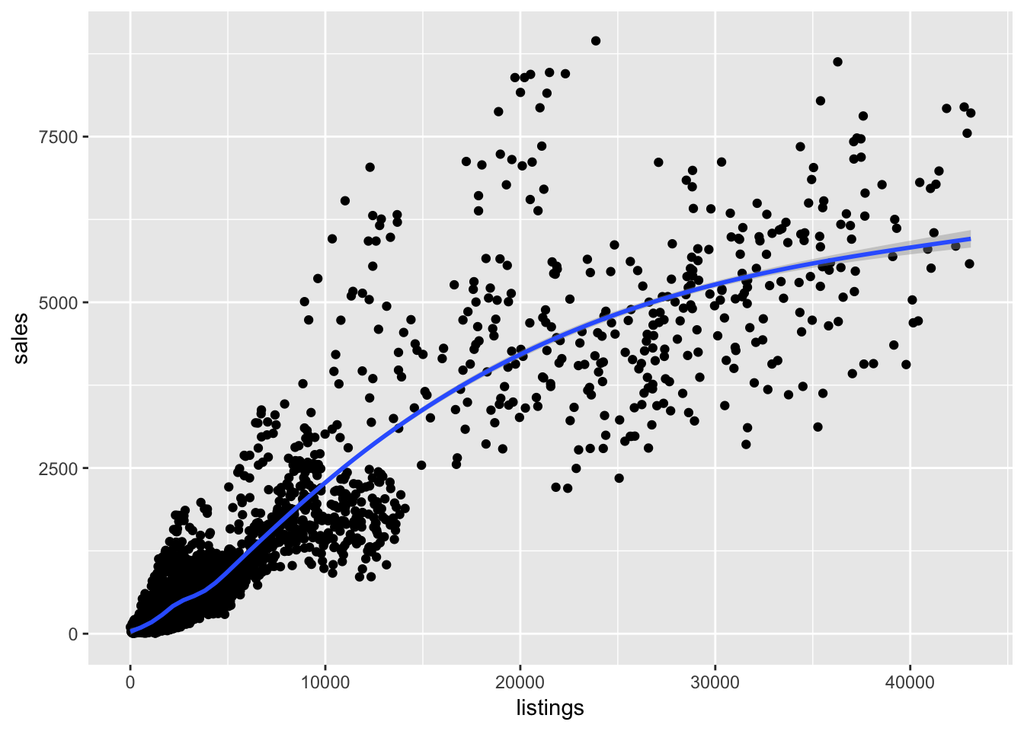

```r
ggplot(data=txhousing, mapping = aes(x=listings, y=sales))+
    geom_point() +
    geom_smooth()
```

The bigger the listings the bigger the number of sales.

#### 5. What proportion of sales is missing for each city?

```r
txhousing %>%
    group_by(city) %>%
    mutate(missing_sales=case_when(is.na(sales) ~ 1,
                                   !is.na(sales) ~0)) %>%
    summarize(missing_sales_perc=sum(missing_sales)/n())
```

```
## # A tibble: 46 x 2
##                     city missing_sales_perc
##                    <chr>              <dbl>
##  1               Abilene         0.00000000
##  2              Amarillo         0.00000000
##  3             Arlington         0.00000000
##  4                Austin         0.00000000
##  5              Bay Area         0.00000000
##  6              Beaumont         0.00000000
##  7       Brazoria County         0.07486631
##  8           Brownsville         0.01069519
##  9 Bryan-College Station         0.00000000
## 10         Collin County         0.00000000
## # ... with 36 more rows
```

#### 6. Looking at only the cities and months with greater than 500 sales:

#### • Are the distributions of the median sales price (column name median), when grouped by city, different? The same? Show your work.

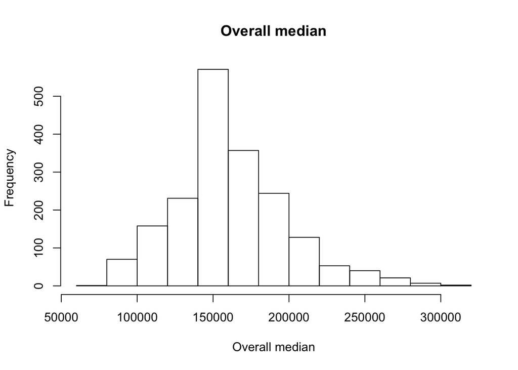

```r
txhouse_500 <- txhousing[txhousing$sales>500,]
hist(txhouse_500$median,xlab='Overall median',main='Overall median')
```

```r
mean(txhouse_500$median, na.rm = TRUE)
```

```
## [1] 161842.4
```

```r
sd(txhouse_500$median, na.rm = TRUE)
```

```
## [1] 36545.78
```

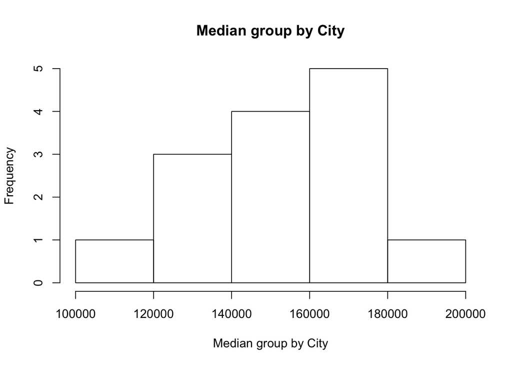

```r
txhouse_500_by_city <- txhouse_500 %>% filter(median != is.na(median)) %>%
    group_by(city) %>% summarize(median_new=median(median),sales_count=sum(sales))
hist(txhouse_500_by_city$median_new,xlab='Median group by City',main='Median group by City')
```

```r
mean(txhouse_500_by_city$median_new, na.rm = TRUE)
```

```
## [1] 154464.3
```

```r
sd(txhouse_500_by_city$median_new, na.rm = TRUE)
```

```
## [1] 23444.5
```

```r
txhouse_500_by_city[order(txhouse_500_by_city$median_new),]
```

```
## # A tibble: 14 x 3
##                 city median_new sales_count
##                <chr>      <dbl>       <dbl>
##  1        Fort Worth     114600      138022
##  2         Arlington     129300       23000
##  3    Corpus Christi     129300        2626
##  4           El Paso     131200       41114
##  5       San Antonio     143300      322097
##  6           Houston     148400     1043999
##  7            Dallas     154500      816122
##  8          Bay Area     156250       52194
##  9 NE Tarrant County     160800      115579
## 10     Denton County     163200       94843
## 11         Fort Bend     177500      148153
## 12 Montgomery County     178750       72994
## 13            Austin     179400      373381
## 14     Collin County     196000      201943
```

#### • Any cities that stand out that you’d want to investigate further?

I will investigate Corpus Christi and Houston. Corpus Christi has the low sales count and low sales median. Houston has high sales count and low sales median.

#### • Why might we want to filter out all cities and months with sales less than 500?

The median may not be correct when the sample is not big enough.

### H. Git and Github (1.5 points)